# discrimability

Greg Kiar

January 13, 2017

# 1 Discriminability in a Nutshell

We are going to generate data from two classes (circles and squares), and demonstrate the strength of discriminability through evaluating different sampling or processing strategies. We construct our two class distributions, sample points from them, reconstruct the object, compute the discriminability of the processing. Discriminability is: computing distance between all pairs of objects, rank the distances, compute the histogram of same-class ranks, and compute the mean rank of the distribution.

Before getting started, we will define a few helpful functions and variables which will streamline this process.

## 1.1 Setup

### 1.1.1 Package Imports

```r
library(abind)
library(rmarkdown)
library(knitr)
library(RColorBrewer)
library(gplots)
sapply(X=dir('../../Code/FlashRupdated/functions/', full.names = TRUE), FUN = source, verbose=FALSE)
graphics.off()
set.seed(123456789)
```

### 1.1.2 Variables

```r
lweight <- 4
len <- 500
nsamples <- 9
nsims <- 3
noise1 <- 0.2
tsize <- 4
nsize <- 3
darkcol <- '#28282e'
medcol <- '#98929e'
lightcol <- '#b8b2be'
darkishcol <- '#48424e'
```

### 1.1.3 Distribution functions

```r
circle <- function(){
  theta <- seq(from = 0, to = 2*pi - pi/len, by = 2*pi/len)
  x <- cos(theta)
  y <- sin(theta)
  circ <- list(x, y)
}

square <- function(){
  range <- seq(from = -1, to = 1, by = 2/(len/4))
  static <- rep(1, each = len/4)
  x <- c(range, static, -range, -static)
  y <- c(static, -range, -static, range)
  sqr <- list(x, y)
}
```

### 1.1.4 Plotting functions

```r
plotshape <- function(xs, ys, typ, cols=medcol){
  size <- lweight
  if (typ == 'p'){
    size <- size/3
  }
  plot(xs, ys, type=typ, axes=FALSE, xlab='', ylab='', pch=20, asp=1, lwd=size, xlim=c(-1, 1), col=darkcol)
  if (typ == 'l'){
    polygon(x=xs, y=ys, col=cols)
  }
}

plotheatmap <- function(data, title=""){
  cols <- colorRampPalette(c("green", "yellow", "red"))(n = 299)
  cols <- c('gray43', cols)
  heatmap.2(data, cellnote=round(data,1), Colv=NA, Rowv=NA, trace="none",
            density.info="none", notecol="black", col=cols, notecex=nsize,
            labRow="", labCol="", key=FALSE, lwid=c(.5,6), lhei=c(.5,6),
            margins=c(4.5,4.5), dendrogram="none")
  par(xpd=NA)
  text(x=0.48, y=1.05, title, cex=nsize)
}

plothistogram <- function(data, title=""){
  layout(1)
  h <- hist(data, breaks=seq(0, 1, l=20), plot=FALSE)
  hist(data, prob=TRUE, col="grey", breaks=seq(0, 1, l=20), ylab="",
       xlab="", main="", xlim=c(0, 1), axes=FALSE)
  d1 <- density(data, bw=0.05, from=0, to=1)
  lines(d1, col="blue", lwd=lweight)
  lines(density(data, bw=0.1, from=0, to=1), lty="dotted", col="darkgreen", lwd=lweight)

  mx <- max(h$count)
  text(x=0, y=-mx/15, "0", cex=nsize-1)
  text(x=1, y=-mx/15, "1", cex=nsize-1)
  text(x=0.5, y=-mx/10, "Normalized Rank", cex=tsize-1)

  mnr <- mean(data)
  score <- paste("MNR:", as.character(round(mnr, 2)))
  lines(c(mnr, mnr), c(0, mx+1), col="red", lwd=lweight)
  text(x=0.5, y=mx+(mx/3), paste(title, score, sep="\n"), cex=nsize)
}

plotseries <- function(x, y, xlab, ylab, fn, title=""){
  layout(1)
  plot(x, y, type="l", xlab=xlab, ylab="", cex.lab=nsize-1, col="blue", axes=FALSE, lwd=lweight)
  lines(x, y, col="black", type="p", lwd=lweight)

  maxy = fn(y)
  lines(c(x[y==maxy], x[y==maxy]), c(0, 1000), col="red", lwd=lweight)

  axis(side=1, at=c(min(x), x[y==maxy], max(x)), lwd=lweight, cex.axis=nsize-1)
  axis(side=2, at=c(min(y), max(y)), lwd=lweight, cex.axis=nsize-1)
  shift <- (range(y)[2] - range(y)[1])*.05
  text(x=(range(x)[2]+range(x)[1])/3, y=max(y)-shift, ylab, cex=tsize)
}
```

### 1.1.5 Sampling functions

```r
sample2 <- function(data, n){
  pts <- floor(runif(n, min=1, max=len))
  xs <- data[[1]]
  x <- xs[pts] + noise1*runif(n, min=-1, max=1)
  x <- c(x, x[1])
  ys <- data[[2]]
  y <- ys[pts] + noise1*runif(n, min=-1, max=1)
  y <- c(y, y[1])
  samp <- list(x, y)
}

sample1 <- function(data, n){
  pts <- sort(floor(runif(n, min=1, max=len)))
  xs <- data[[1]]
  x <- xs[pts] + noise1*runif(n, min=-1, max=1)
  x <- c(x, x[1])
  ys <- data[[2]]
  y <- ys[pts] + noise1*runif(n, min=-1, max=1)
  y <- c(y, y[1])
  samp <- list(x, y)
}
```

### 1.1.6 Utility functions

```r
distances <- function(data, title="", plot=FALSE){
  diff <- matrix(data=NA, nrow=2*nsims, ncol=2*nsims)
  for (i in 1:(2*nsims)){
    for (j in 1:(2*nsims)){
      diff[i,j] <- norm(data[,,i] - data[,,j], '2')
    }
  }
  if (plot) {
    plotheatmap(diff, title=title)
  }
  return(diff)
}

simulate_shape <- function(fn, sampling, nsamples, plot=FALSE, cols=lightcol){
  layout(matrix(c(1,2,3, 1,4,5, 1,6,7), 3, 3, byrow = TRUE))
  par(xpd=NA)
  shape <- fn()
  if (plot) {
    plotshape(shape[[1]], shape[[2]], 'l', cols)

    arrows(x0=1.2, x1=2.2, y0=1, y1=1.5, length=0.1, lwd = lweight)
    arrows(x0=1.3, x1=2.2, y0=0, y1=0, length=0.1, lwd = lweight)
    arrows(x0=1.2, x1=2.2, y0=-1, y1=-1.5, length=0.1, lwd = lweight)
    text(x=1.5, y=1.5, expression('s'[1]^'a'), cex=tsize)
    text(x=1.7, y=0.3, expression('s'[2]^'a'), cex=tsize)
    text(x=1.5, y=-1.5, expression('s'[3]^'a'), cex=tsize)

    arrows(x0=3.5, x1=4.8, y0=1.5, y1=1.5, length=0.1, lwd=lweight)
    arrows(x0=3.5, x1=4.8, y0=0, y1=0, length=0.1, lwd=lweight)
    arrows(x0=3.5, x1=4.8, y0=-1.5, y1=-1.5, length=0.1, lwd=lweight)

    text(x=4.15, y=1.8, bquote(p[.(1)]^'a'), cex=tsize)
    text(x=4.15, y=0.3, bquote(p[.(2)]^'a'), cex=tsize)
    text(x=4.15, y=-1.2, bquote(p[.(3)]^'a'), cex=tsize)
  }

  label <- c()
  data <- array(data=NA, c(2, nsamples, nsims))
  dim(data)
  for (i in 1:nsims){
    samp <- sampling(shape, nsamples)
    if (i <= 3){
      if (plot) {
        plotshape(samp[[1]], samp[[2]], 'p')
        plotshape(samp[[1]], samp[[2]], 'l')
      }
    }
    data[1, ,i] <- samp[[1]][1:nsamples]
    data[2, ,i] <- samp[[2]][1:nsamples]
    label <- c(label, as.character(substitute(fn)))
  }
  values <- list(label, data)
}
```

## 1.2 1-Sample Test-Statistic

### 1.2.1 Sampling Shapes

We will start by sampling data from the circle distribution and reconstructing the shapes from each set of samples.

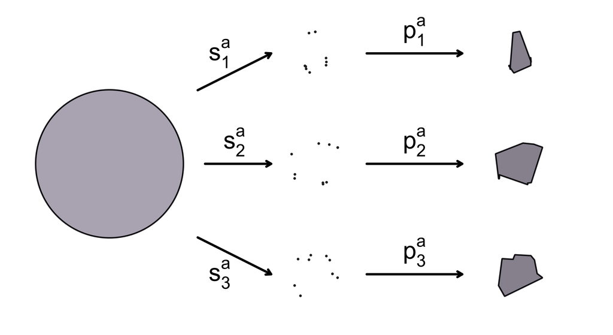

```r
vals <- simulate_shape(circle, sample1, nsamples, plot=TRUE, lightcol)
```

```r
labels <- vals[[1]]
data <- vals[[2]]
```

The same process is then repeated for the square distribution.

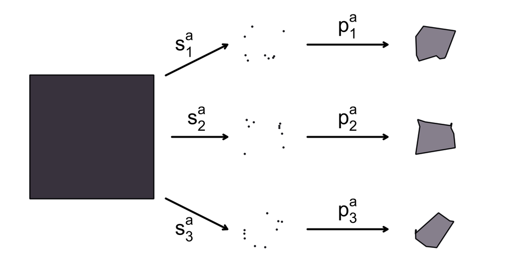

```r
vals <- simulate_shape(square, sample1, nsamples, plot=TRUE, darkishcol)
```

```r
labels <- c(labels, vals[[1]])
data <- abind(data, vals[[2]])
```

### 1.2.2 Compute distances

Now we have a data matrix which contains `x` and `y` sampled values, and a list of labels for each sample identifying whether it belongs to the “circle” or “square” distribution. We can then compute the distance between observations in each class.

```r
print(labels)
```

```
# [1] "circle" "circle" "circle" "square" "square" "square"
```

```r
print(dim(data))
```

```
# [1] 2 9 6
```

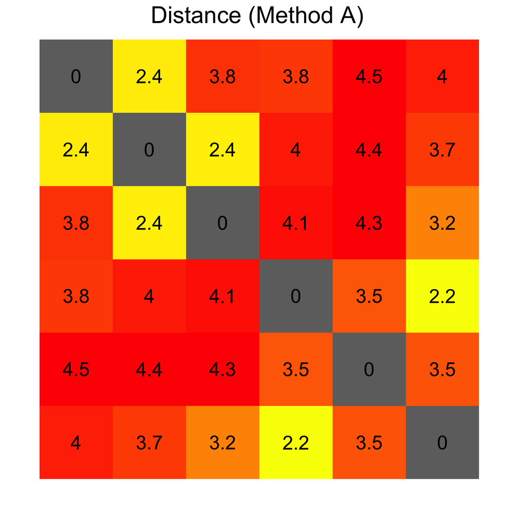

```r
diff <- distances(data, title="Distance (Method A)", plot=TRUE)
```

### 1.2.3 Rank distances

Next, we can rank this matrix to observe the distances between objects in- and across- class, and compute the rank distribution function (rdf) of our processed data.

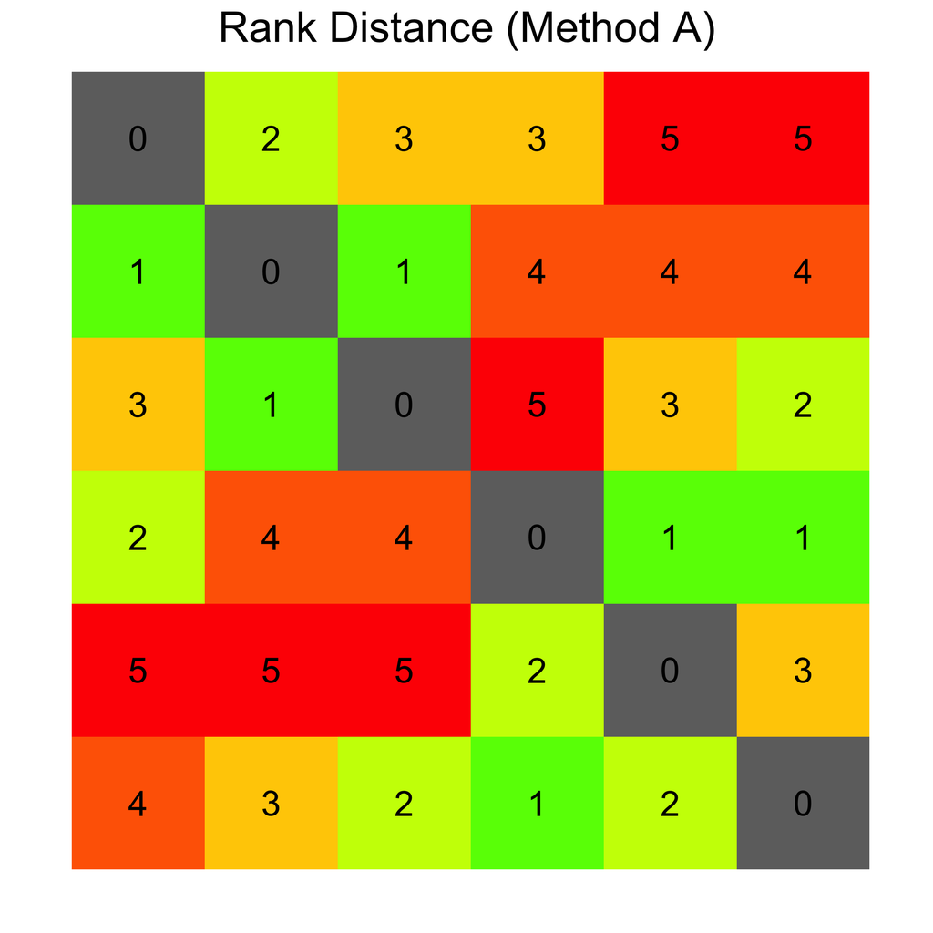

```r
rankmatrix <- apply(diff, 1, rank, ties.method="average") - 1
plotheatmap(rankmatrix, "Rank Distance (Method A)")
```

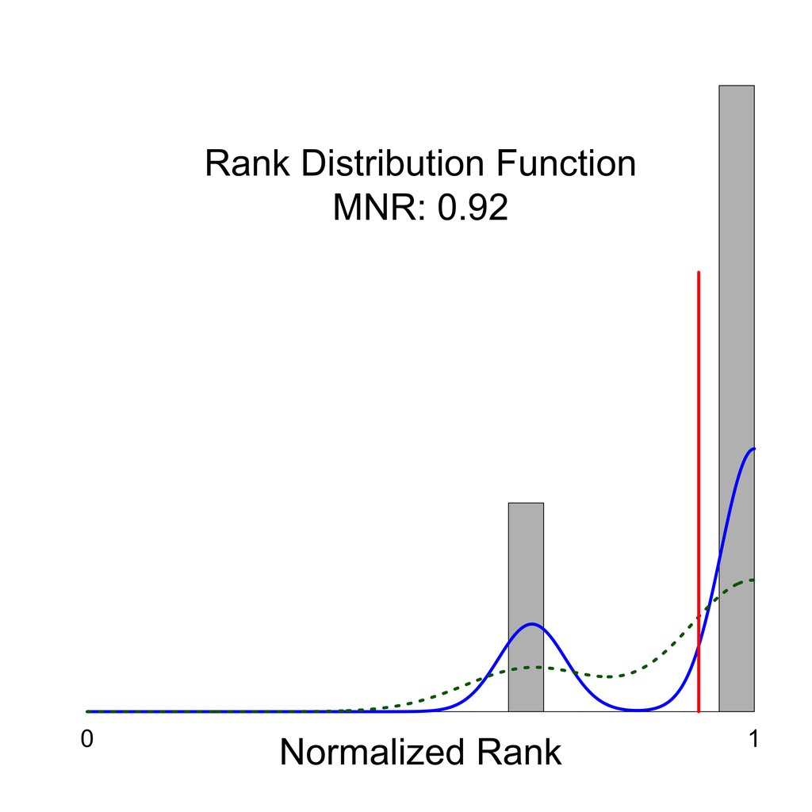

```r
ranks <- rdf(diff, labels)
plothistogram(ranks, "Rank Distribution Function")
```

## 1.3 2-Sample Test Statistic

To use discriminability as a 2-sample test statistic, we simply need to repeat the process for a different sampling/processing, and compare the two statistics

### 1.3.1 Sampling Shapes

Here, to illustrate a potentially worse strategy, we are forgetting to “align” the samples before constructing the shapes and them, for instance.

```r
vals <- simulate_shape(circle, sample2, nsamples)
labels <- vals[[1]]
data <- vals[[2]]

vals <- simulate_shape(square, sample2, nsamples)
labels <- c(labels, vals[[1]])
data <- abind(data, vals[[2]])
```

### 1.3.2 Compute distances

Just as before we compute distances (noticing this is quite a bit worse).

```r
print(labels)
```

```
# [1] "circle" "circle" "circle" "square" "square" "square"
```

```r
print(dim(data))
```

```
# [1] 2 9 6
```

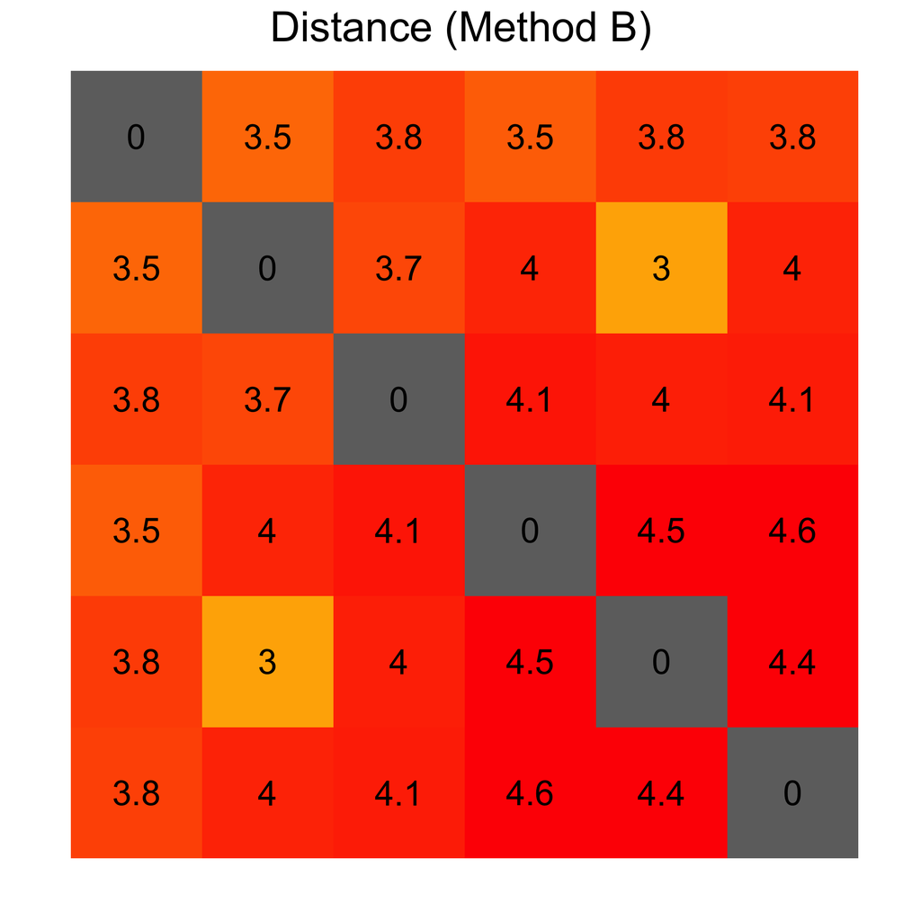

```r
diff <- distances(data, title="Distance (Method B)", plot=TRUE)
```

### 1.3.3 Rank distances

Ranking and computing the RDF will again illustrate that the method is worse than our previous method.

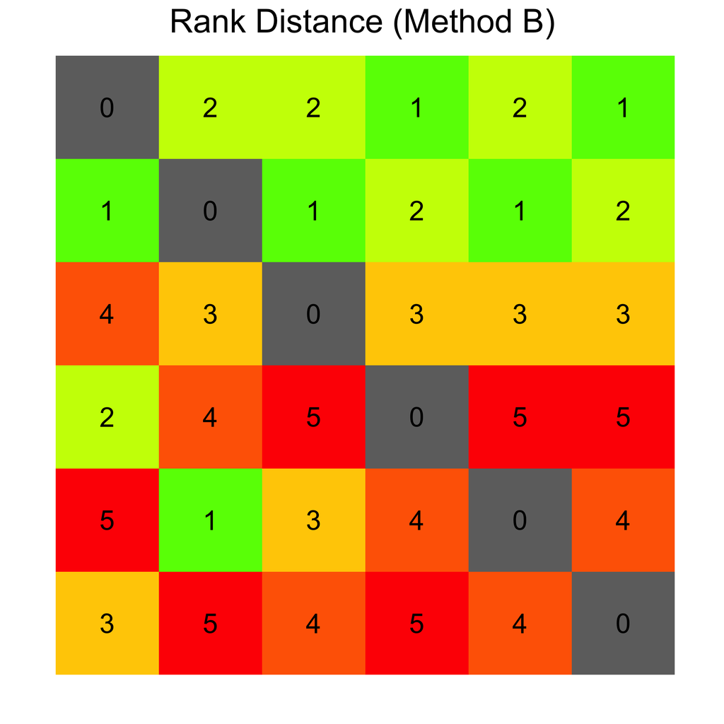

```r
rankmatrix <- apply(diff, 1, rank, ties.method="average") - 1
plotheatmap(rankmatrix, "Rank Distance (Method B)")
```

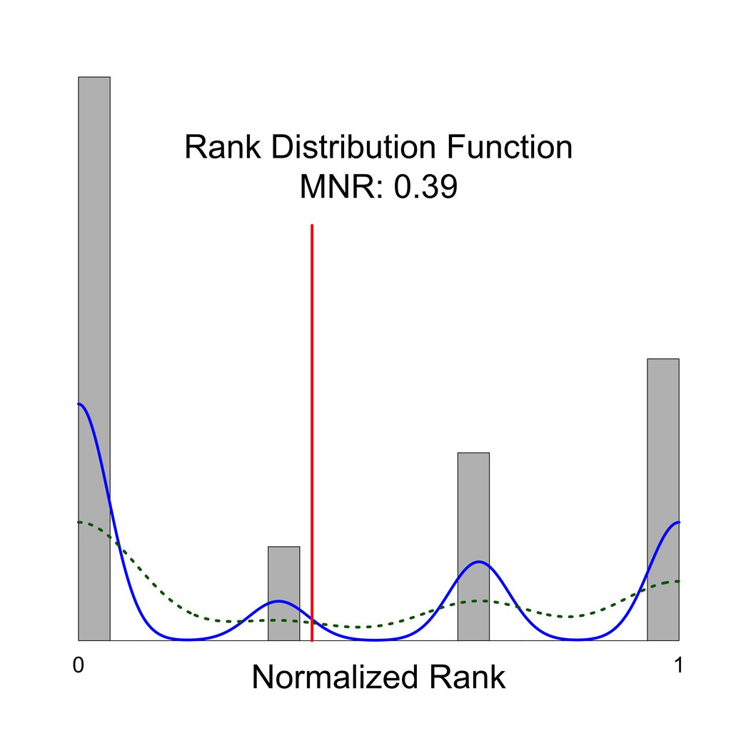

```r
ranks <- rdf(diff, labels)
plothistogram(ranks, "Rank Distribution Function")
```

### 1.3.4 Scoring multiple operating points

Performing this analysis as a k-sample test (i.e. score discriminability for multiple apps), we can pick the operating point that maximizes our discriminability score to be used for further investigation.

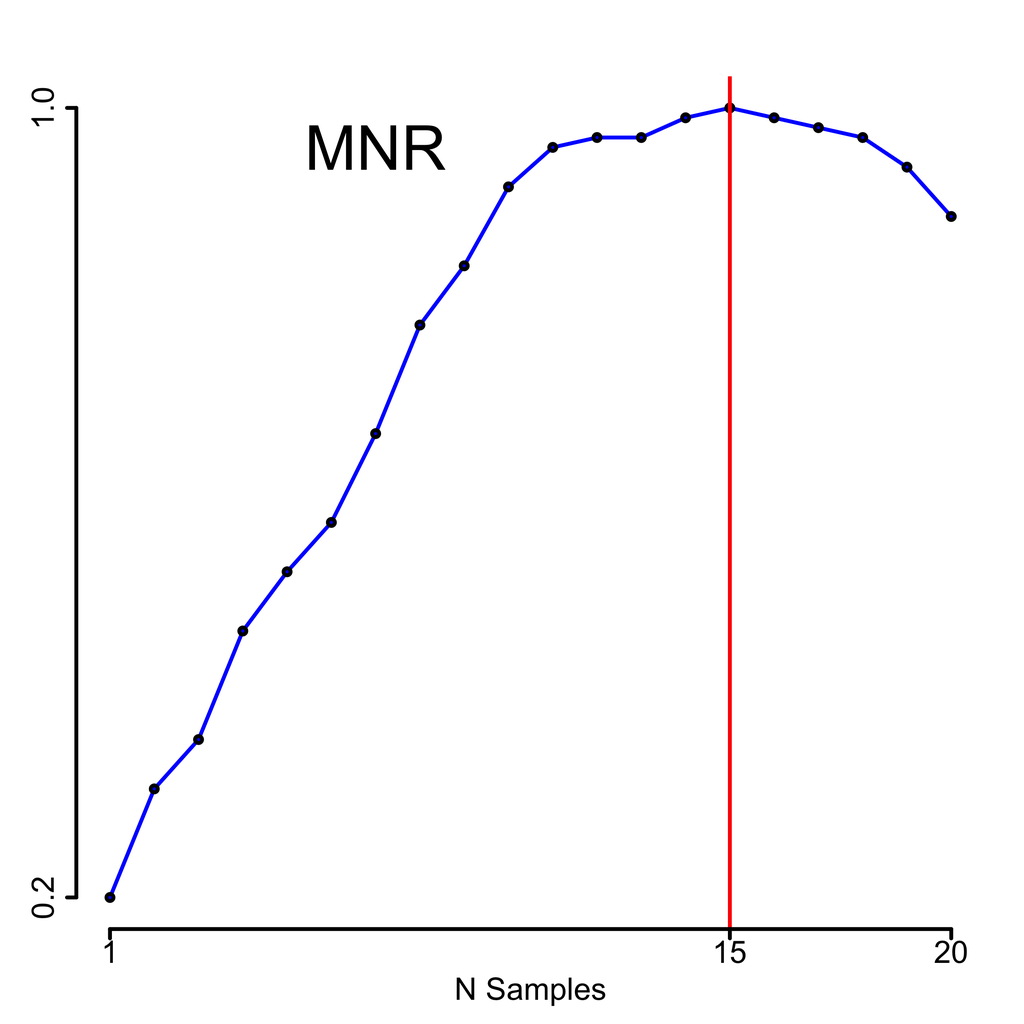

```r
samp <- c(  1,  2,    3,   4,   5,   6,   7,   8,   9,  10,  11,  12,  13,  14, 15,  16,  17,  18,  19,  20)
mnrs <- c( .2, .31, .36, .47, .53, .58, .67, .78, .84, .92, .96, .97, .97, .99,  1, .99, .98, .97, .94, .89)
plotseries(samp, mnrs, 'N Samples', 'MNR', max)
```

### 1.3.5 Performing a task with the optimal pipeline

Using the pipeline that optimizes discriminability for a downstream inference task will also optimize performance on that task.

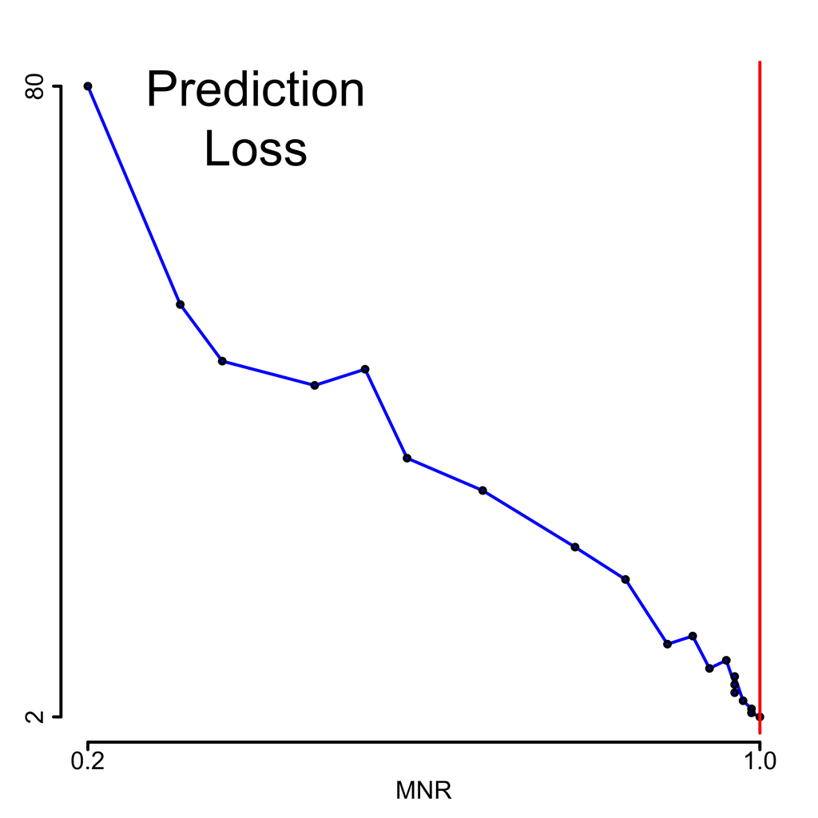

```r
mnrs <- c( .2, .31, .36, .47, .53, .58, .67, .78, .84, .92, .96, .97, .97, .99,  1, .99, .98, .97, .94, .89)
loss <- c( 80,  53,  46,  43,  45,  34,  30,  23,  19,  12,   9,   6,   5,   3,  2, 2.5,   4,   7,   8,  11)

sortz = order(mnrs, decreasing = FALSE)
mnrs <- mnrs[sortz]
loss <- loss[sortz]
plotseries(mnrs, loss, 'MNR', 'Prediction\nLoss', min)
```